# RepResearch_PeerAssessment2

# Impact of Severe Weather Events on Public Health and Economy in the US

## Synopsis

This project uses the U.S. NOAA storm database to explore the most severe weather events for human health and economy in the US. The NOAA Storm Database records the major storm and severe weather events in the US from 1950 to 2011. The basic goal of this assignment is to analyse this database, to address the following questions:

1. Which weather types are most harmful for population health?
2. Which weather types cause most economic damage?

To do this analysis the data from the database was processed to obtain the relevant information as followed:

## Basic setting and download of the data

```r
echo = TRUE
options(scipen = 1)
library(plyr)

# find data and download
if (!file.exists("StormData.csv.bz2")) {
  download.file("https://d396qusza40orc.cloudfront.net/repdata%2Fdata%2FStormData.csv.bz2", destfile="StormData.csv.bz2", method="curl")
}
# read data in
stormdata <- read.csv(bzfile("StormData.csv.bz2"), header=TRUE, stringsAsFactors=FALSE)

# show columns
head(stormdata, 3)
```

```
##   STATE__          BGN_DATE BGN_TIME TIME_ZONE COUNTY COUNTYNAME STATE
## 1       1 4/18/1950 0:00:00     0130       CST     97     MOBILE    AL
## 2       1 4/18/1950 0:00:00     0145       CST      3    BALDWIN    AL
## 3       1 2/20/1951 0:00:00     1600       CST     57    FAYETTE    AL
##    EVTYPE BGN_RANGE BGN_AZI BGN_LOCATI END_DATE END_TIME COUNTY_END
## 1 TORNADO         0                                               0
## 2 TORNADO         0                                               0
## 3 TORNADO         0                                               0
##   COUNTYENDN END_RANGE END_AZI END_LOCATI LENGTH WIDTH F MAG FATALITIES
## 1         NA         0                      14.0   100 3   0          0
## 2         NA         0                       2.0   150 2   0          0
## 3         NA         0                       0.1   123 2   0          0
##   INJURIES PROPDMG PROPDMGEXP CROPDMG CROPDMGEXP WFO STATEOFFIC ZONENAMES
## 1       15    25.0          K       0
## 2        0     2.5          K       0
## 3        2    25.0          K       0
##   LATITUDE LONGITUDE LATITUDE_E LONGITUDE_ REMARKS REFNUM
## 1     3040      8812       3051       8806              1
## 2     3042      8755          0          0              2
## 3     3340      8742          0          0              3
```

```r
dim(stormdata)
```

```
## [1] 902297     37
```

```r
# number of different cases of EVTYPE
length(unique(stormdata$EVTYPE))
```

```
## [1] 985
```

There are 37 columns and 902297 rows of data from 1950 to 2011. There are 985 event types in column EVTYPE.

## Data processing

1. We reduce the number of columns in the data to the data we will need for our analysis.
2. For simplification, we change the eventtypes and the exponent columns to lower case.

```r
# select the important columns for the analysis

reducedcol <- c("BGN_DATE", "EVTYPE", "FATALITIES", "INJURIES", "PROPDMG", "PROPDMGEXP", "CROPDMG", "CROPDMGEXP")

reduceddata <- stormdata[reducedcol]

# EVTYPE and PROPDMGEXP and CROPDMGEXP to lower case

lowevty <- tolower(reduceddata$EVTYPE)
lowexp1 <- tolower(reduceddata$PROPDMGEXP)
lowexp2 <- tolower(reduceddata$CROPDMGEXP)

reduceddata$EVTYPE <- lowevty
reduceddata$PROPDMGEXP <- lowexp1
reduceddata$CROPDMGEXP <- lowexp2

rm("lowevty", "lowexp1", "lowexp2")
```

3. Then we add an additional column indicating the year of the events. Using this year data we make an histogram to get an overview of the data.

```r
# sets BGN_DATe as numeric and a date
reduceddata$YEAR <- as.numeric(format(as.Date(reduceddata$BGN_DATE, format = "%m/%d/%Y %H:%M:%S"), "%Y"))

# show that YEAR is added
head(reduceddata, 2)
```

```
##            BGN_DATE  EVTYPE FATALITIES INJURIES PROPDMG PROPDMGEXP CROPDMG
## 1 4/18/1950 0:00:00 tornado          0       15    25.0          k       0
## 2 4/18/1950 0:00:00 tornado          0        0     2.5          k       0
##   CROPDMGEXP YEAR
## 1            1950
## 2            1950
```

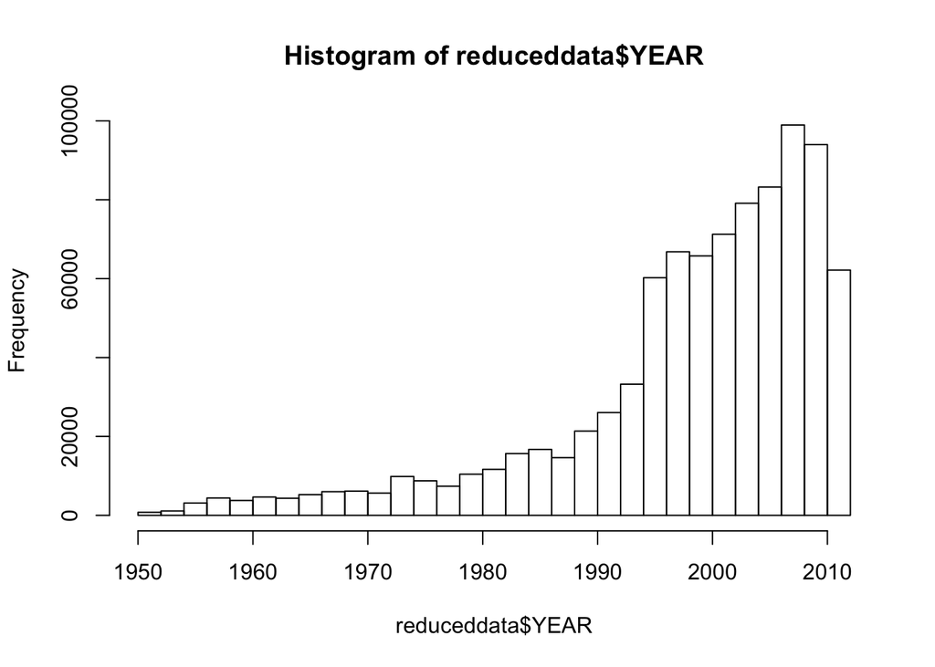

```r
# make a histogramm of the data per year
hist(reduceddata$YEAR, breaks = 40)
```

The majority of events is recorded after 1995. 4. We reduce the data by discarding all events before 1995. This is also to improve data quality, as recording is more standarized in this period.

```r
# data from 1996 to 2011
eventnew <- reduceddata[ which(reduceddata$YEAR >= 1995), ]
```

5. We are interested in the events that resulted in injuries/fatalities or economic damage (property and crop). So we discard all data with no/0 entry in all of these columns.

```r
# removes all rows with zero DMG/INJURIES/FATALATIES
eventnew <- eventnew[rowSums(eventnew[ , c( 3, 4, 5, 7)]) > 0, ]
```

6. Now we try to reduce the “messy” event type data by pooling some similar event types. I did not do this for all. Just to reduce it a bit.

```r
# try to reduce the different cases for EVTYPE
eventnew[grepl("wind|winds|typhoon|hurricane", eventnew$EVTYPE, ignore.case = TRUE), "event"] <- "wind&hurricane"
eventnew[grepl("tstm|thunderstorm", eventnew$EVTYPE, ignore.case = TRUE), "event"] <- "thunderstorm"
eventnew[grepl("cold|icy|ice|chill|freeze|frost", eventnew$EVTYPE, ignore.case = TRUE), "event"] <- "cold&ice"
eventnew[grepl("tornado", eventnew$EVTYPE, ignore.case = TRUE), "event"] <- "tornado"
eventnew[grepl("snow", eventnew$EVTYPE, ignore.case = TRUE), "event"] <- "snow&ice"
eventnew[grepl("flood", eventnew$EVTYPE, ignore.case = TRUE), "event"] <- "flood"

eventnew$event <- replace(eventnew$event, which(is.na(eventnew$event) ==TRUE), "0")
eventnew$DMGEVENT <- ifelse (eventnew$event == 0,  eventnew$DMGEVENT <- eventnew$EVTYPE, eventnew$DMGEVENT <- eventnew$event)

eventnew$event <- NULL
eventnew$EVTYPE <- NULL

tail(eventnew, 5)
```

```
##                  BGN_DATE FATALITIES INJURIES PROPDMG PROPDMGEXP CROPDMG
## 902250  11/9/2011 0:00:00          0        0     5.0          k       0
## 902255 11/23/2011 0:00:00          0        0     0.6          k       0
## 902257 11/13/2011 0:00:00          0        0     1.0          k       0
## 902259  11/1/2011 0:00:00          0        0     2.0          k       0
## 902260 11/30/2011 0:00:00          0        0     7.5          k       0
##        CROPDMGEXP YEAR       DMGEVENT
## 902250          k 2011   winter storm
## 902255          k 2011 wind&hurricane
## 902257          k 2011 wind&hurricane
## 902259          k 2011        drought
## 902260          k 2011 wind&hurricane
```

```r
length(unique(eventnew$DMGEVENT))
```

```
## [1] 135
```

Now, the data has 135 event types (reduced from 985).

7. This will change the property and crop damage to real numerical values and remove the exponent column.

```r
# change the exp to numbers
eventnew$PEXP <- ifelse(eventnew$PROPDMGEXP == "k", 3,
                        ifelse(eventnew$PROPDMGEXP == "h", 2,
                               ifelse(eventnew$PROPDMGEXP == "m", 6,
                                      ifelse(eventnew$PROPDMGEXP == "b", 9, 0))))

eventnew$CEXP <- ifelse(eventnew$CROPDMGEXP == "k", 3,
                        ifelse(eventnew$CROPDMGEXP == "h", 2,
                               ifelse(eventnew$CROPDMGEXP == "m", 6,
                                      ifelse(eventnew$CROPDMGEXP == "b", 9, 0))))
# calculates the money value
eventnew$PROPDAMAGE <- eventnew$PROPDMG * 10^eventnew$PEXP
eventnew$CROPDAMAGE <- eventnew$CROPDMG * 10^eventnew$CEXP
# removes these columns
eventnew$PROPDMG <- NULL
eventnew$CROPDMG <- NULL
eventnew$PROPDMGEXP <- NULL
eventnew$CROPDMGEXP <- NULL
eventnew$PEXP <- NULL
eventnew$CEXP <- NULL

tail(eventnew,5)
```

```
##                  BGN_DATE FATALITIES INJURIES YEAR       DMGEVENT
## 902250  11/9/2011 0:00:00          0        0 2011   winter storm
## 902255 11/23/2011 0:00:00          0        0 2011 wind&hurricane
## 902257 11/13/2011 0:00:00          0        0 2011 wind&hurricane
## 902259  11/1/2011 0:00:00          0        0 2011        drought
## 902260 11/30/2011 0:00:00          0        0 2011 wind&hurricane
##        PROPDAMAGE CROPDAMAGE
## 902250       5000          0
## 902255        600          0
## 902257       1000          0
## 902259       2000          0
## 902260       7500          0
```

# Results

## Injuries and Fatalities

Which weather events have the most impact on public health (in terms of injuries and fatalaties)?

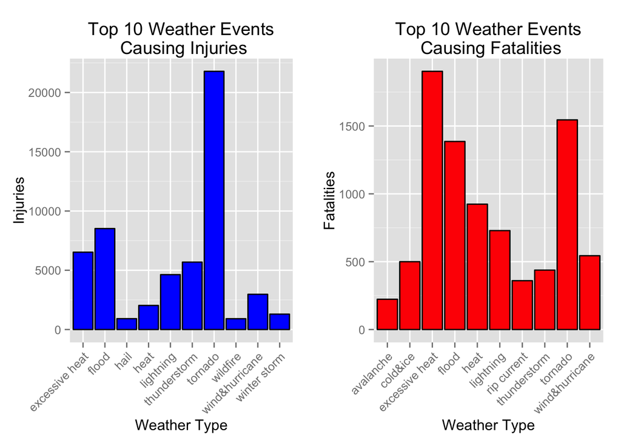

```r
library(ggplot2)
library(gridExtra)
# results injuries & fatalities
# makes two data frames containing the top 10 events causing injuries and fatalaties
injuries <- aggregate(eventnew$INJURIES, by = list(eventnew$DMGEVENT), "sum")
names(injuries) <- c("event", "injuries")
injuries <- arrange(injuries, desc(injuries))
topinjuries <- injuries[1:10,]

fatalities <- aggregate(eventnew$FATALITIES, by = list(eventnew$DMGEVENT), "sum")
names(fatalities) <- c("event", "fatalities")
fatalities <- arrange(fatalities, desc(fatalities))
topfatalities <- fatalities[1:10,]

# makes the plot
ploti <- ggplot(data = topinjuries, aes(event, y = injuries))
ploti <- ploti + geom_bar(colour = "black", fill = "blue", stat="identity")
ploti <- ploti + theme(axis.text.x = element_text(angle = 45, hjust = 1))
ploti <- ploti + labs(x="Weather Type", y="Injuries", title="Top 10 Weather Events\n Causing Injuries")

plotf <- ggplot(data = topfatalities, aes(event, y = fatalities))
plotf <- plotf + geom_bar(colour = "black", fill = "red", stat="identity")
plotf <- plotf + theme(axis.text.x = element_text(angle = 45, hjust = 1))
plotf <- plotf + labs(x="Weather Type", y="Fatalities", title="Top 10 Weather Events\n Causing Fatalities")

grid.arrange(ploti, plotf, ncol=2)
```

The data shows that most injuries are caused by tornados. Heat is the most frequent cause of death and tornados are the second most frequent.

## Property and Crop Damage

Which weather types have the most economic consequences?

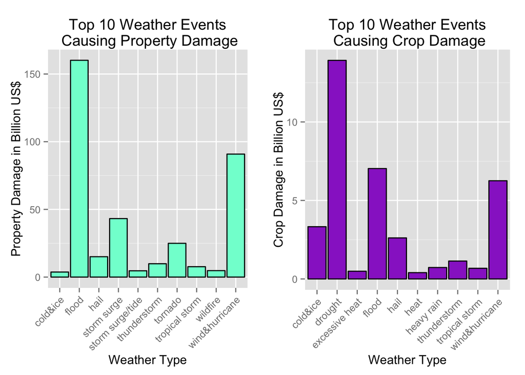

```r
# damage, makes two data frames for top 10 property and crop damage events (this is perhaps not necessary...)
prop <- aggregate(eventnew$PROPDAMAGE, by = list(eventnew$DMGEVENT), "sum")
names(prop) <- c("event", "propdamage")
prop <- arrange(prop, desc(propdamage))
topprop <- prop[1:10,]

crop <- aggregate(eventnew$CROPDAMAGE, by = list(eventnew$DMGEVENT), "sum")
names(crop) <- c("event", "cropdamage")
crop <- arrange(crop, desc(cropdamage))
topcrop <- crop[1:10,]

# makes the plot
plotp <- ggplot(data = topprop, aes(event, y = propdamage / 1000000000))
plotp <- plotp + geom_bar(colour = "black", fill = "aquamarine", stat="identity")
plotp <- plotp + theme(axis.text.x = element_text(angle = 45, hjust = 1))
plotp <- plotp + labs(x="Weather Type", y="Property Damage in Billion US$", title="Top 10 Weather Events\n Causing Property Damage")

plotc <- ggplot(data = topcrop, aes(event, y = cropdamage / 1000000000))
plotc <- plotc + geom_bar(colour = "black", fill = "darkorchid", stat="identity")
plotc <- plotc + theme(axis.text.x = element_text(angle = 45, hjust = 1))
plotc <- plotc + labs(x="Weather Type", y="Crop Damage in Billion US$", title="Top 10 Weather Events\n Causing Crop Damage")

grid.arrange(plotp, plotc, ncol=2)
```

Flooding caused the most property damage. Drought caused the most crop damage, followed by flood and hurricane types of wind.

## Summary

Tornados caused by far the most injuries, whereas heat caused the most fatalaties. Flooding caused the most property damage and drought the most agricultural damage.